# Using prim to estimate highest density difference regions

Tarn Duong https://mvstat.net/tduong/

28 November 2024

The Patient Rule Induction Method (PRIM) was introduced by Friedman and Fisher (1999). It is a technique from data mining for finding `interesting’ regions in high-dimensional data. We start with regression-type data *(**X**<sub>1</sub>, Y<sub>1</sub>), …, (**X**<sub>n</sub>, Y<sub>n</sub>)* where **X**<sub>i</sub> is *d*-dimensional and *Y<sub>i</sub>* is a scalar response variable. We are interested in the conditional expectation function

*m(**x**) = **E** (Y | **X** = **x**)*.

In the case where we have 2 samples, we can label the response as a binary variable with

*Y<sub>i</sub> = 1* if **X**<sub>i</sub> is in sample 1

or

*Y<sub>i</sub> = -1* if **X**<sub>i</sub> is in sample 2.

Then PRIM finds the regions where the samples are most different. Here we have a positive HDR (where sample 1 points dominate) and a negative HDR (where sample 2 points dominate).

We look at a 3-dimensional data set `quasiflow` included in the `prim` library. It is a randomly generated data set from two normal mixture distributions whose structure mimics some light scattering data, taken from a machine known as a flow cytometer.

```r
library(prim)
data(quasiflow)
yflow <- quasiflow[,4]
xflow <- quasiflow[,1:3]
xflowp <- quasiflow[yflow==1,1:3]
xflown <- quasiflow[yflow==-1,1:3]
```

We can think of `xflowp` as flow cytometric measurements from an HIV+ patient, and `xflown` from an HIV– patient.

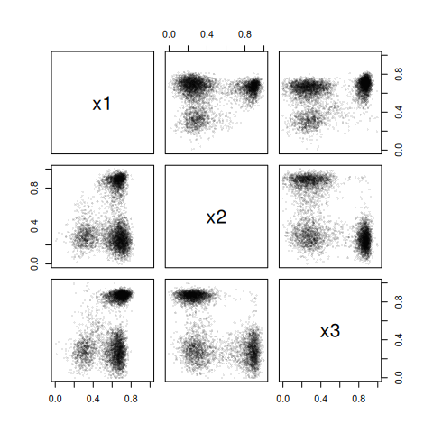

```r
pairs(xflowp, cex=0.5, pch=16, col=grey(0,0.1), xlim=c(0,1), ylim=c(0,1))
```

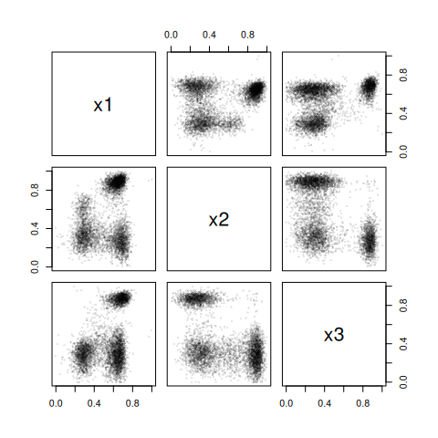

```r
pairs(xflown, cex=0.5, pch=16, col=grey(0,0.1), xlim=c(0,1), ylim=c(0,1))
```

```r
qflow.hdr.pos <- prim.box(x=xflow, y=yflow, threshold=0.38, threshold.type=1)
summary(qflow.hdr.pos)
```

```
#>              box-fun   box-mass threshold.type
#> box1     0.551879699 0.05808875              1
#> box2*   -0.003431327 0.94191125             NA
#> overall  0.028825996 1.00000000             NA
```

On the other hand, we are not sure about the negative HDR thresholds. So we try several different values for `threshold`.

```r
qflow.neg <- prim.box(x=xflow, y=yflow, threshold.type=-1)
qflow.hdr.neg1 <- prim.hdr(qflow.neg, threshold=-0.23, threshold.type=-1)
qflow.hdr.neg2 <- prim.hdr(qflow.neg, threshold=-0.43, threshold.type=-1)
qflow.hdr.neg3 <- prim.hdr(qflow.neg, threshold=-0.63, threshold.type=-1)
```

After examining the summaries and plots,

```r
summary(qflow.hdr.neg1)
```

```
#>            box-fun   box-mass threshold.type
#> box1    -0.6767677 0.05188679             -1
#> box2    -0.3109244 0.05197414             -1
#> box3    -0.2778316 0.09023410             -1
#> box4    -0.2815199 0.05057652             -1
#> box5*    0.1580895 0.75532844             NA
#> overall  0.0288260 1.00000000             NA
```

we choose `qflow.hdr.neg1` to combine with `qflow.hdr.pos`.

```r
qflow.prim2 <- prim.combine(qflow.hdr.pos, qflow.hdr.neg1)
summary(qflow.prim2)
```

```
#>            box-fun   box-mass threshold.type
#> box1     0.5518797 0.05808875              1
#> box2    -0.6767677 0.05188679             -1
#> box3    -0.3109244 0.05197414             -1
#> box4    -0.2778316 0.09023410             -1
#> box5    -0.2815199 0.05057652             -1
#> box6*    0.1252819 0.69723969             NA
#> overall  0.0288260 1.00000000             NA
```

In the plot below, the positive HDR is coloured orange (where the HIV+ sample is more prevalent), and the negative HDR is coloured blue (where the HIV- sample is more prevalent)

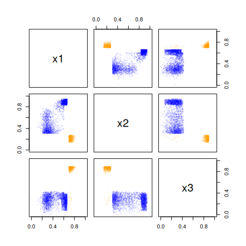

```r
plot(qflow.prim2, x.pt=xflow, pch=16, cex=0.5, alpha=0.1)
```

or equivalently as a 3D scatter plot.

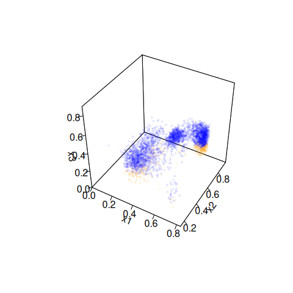

```r
plot(qflow.prim2, x.pt=xflow, pch=16, cex=0.5, alpha=0.1, splom=FALSE, colkey=FALSE, ticktype="detailed")
```

## References

Friedman, J. H. and Fisher, N. I. (1999). Bump-hunting for high dimensional data. *Statistics and Computing*, **9**, 123-143.